# CSCI E-63C Week 11 assignment

# Problem 2 (10 points): comparison to random forest

Fit random forest classifier on the entire banknote authentication dataset with default parameters. Calculate resulting misclassification error as reported by the confusion matrix in random forest output. Explain why error reported in random forest confusion matrix represents estimated test (as opposed to train) error of the procedure. Compare resulting test error to that for support vector classifier obtained above and discuss results of such comparison.

```r
set.seed(1234)
rf <- randomForest(dbaDat[,-5],dbaDat$auth)
rf$confusion
```

```
##     0   1 class.error
## 0 756   6 0.007874016
## 1   1 609 0.001639344
```

```r
1-(sum(diag(rf$confusion))/sum(rf$confusion))
```

```
## [1] 0.005108939
```

```r
## Random Forest does not require a separate cross-validation to estimate test Errors, Breiman [1996b]. The errors from the confusion matrix are the Out of Bag (OOB) errors. So from bootstrapped samples the error is the average error of all test set predictions.

## Test error rate for random fores ist .005 compared to the .008 observed from the SVM. The data is pretty linearly separable so we get good performance on either methods.


set.seed(1)
rf.model <-randomForest(dbaDat[gTrain,-5],gLbl[gTrain])
rf.tab <- table(dbaDat[!gTrain,"auth"], predict(rf.model,newdata=dbaDat[!gTrain,]))

rf.err <-  1-(sum(diag(rf.tab))/sum(rf.tab))
rf.err
```

```
## [1] 0.004160888
```

```r
#Running a single model using same training and test set for comparisons
```

# Extra 7 points problem: effect of `mtry` and `ntree` in random forest

Not directly related to SVM, but while we are at it: fit random forest to the entire banknote authentication dataset for every possible value of parameter `mtry` and using `ntree` of 100 and 1000 for each of them. The values of `mtry` possible in this case are 1, 2, 3 and 4. Please explain what is governed by this parameter and why this is the exhaustive set of the values allowed for it in this case. Would it change for another dataset? What is the default value of `mtry` for this dataset? Repeat this several times to assess center and spread of the error rates produced by random forest with these parameters across multiple runs of random forest procedure. Present these results graphically and comment on the impact of the choices of `mtry` and `ntree` on the resulting error rates.

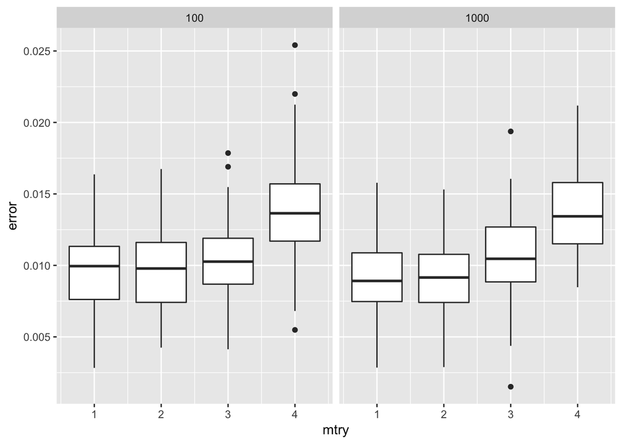

```r
set.seed(1234)
dfTmp <- NULL

for (mtry in 1:4){
    for (ntree in c(100,1000)){
      for (j in 1:100){
      bTrain <- sample(c(FALSE,TRUE),nrow(dbaDat),replace=TRUE)
      cls <- as.factor(dbaDat$auth)
      rf <- randomForest(dbaDat[bTrain,-5],cls[bTrain], mtry = mtry, ntree = ntree)
      dfTmp <- rbind(dfTmp, data.frame(error=1-(sum(diag(rf$confusion))/sum(rf$confusion)),mtry=mtry,ntree=ntree))
      }
    }
}


ggplot(dfTmp, aes(mtry, error, group=mtry)) + geom_boxplot()  + facet_grid(~ntree)
```

```r
#mtry, is the number of parameters that are randomly sampled as candidates at each split. This is bound by the number of variables (in our case: 4).
#Normally mtry is sqrt(ncol(x)), so default should be 2

#Generally, all things being equal, an increase in ntree, from 100 to 1000, leads to a slight decrease in error on our dataset
#We see a slight decrease in variance from mtry 1 to 2 (default), as mtry increases after that, we see an increase in test error
```

# Problem 3 (10 points): Comparison to cross-validation tuned KNN predictor

Use convenience wrapper `tune.knn` provided by the library `e1071` on the entire dataset to determine optimal value for the number of the nearest neighbors ‘k’ to be used in KNN classifier. Consider our observations in week 9 assignment when choosing range of values of `k` to be evaluated by `tune.knn`. Setup resampling procedure similar to that used above for support vector classifier that will repeatedly: a) split banknote authentication dataset into training and test, b) use `tune.knn` on training data to determine optimal `k`, and c) use `k` estimated by `tune.knn` to make KNN classifications on test data. Report and discuss distributions of test errors from this procedure and selected values of `k`, compare them to those obtained for random forest and support vector classifier above.

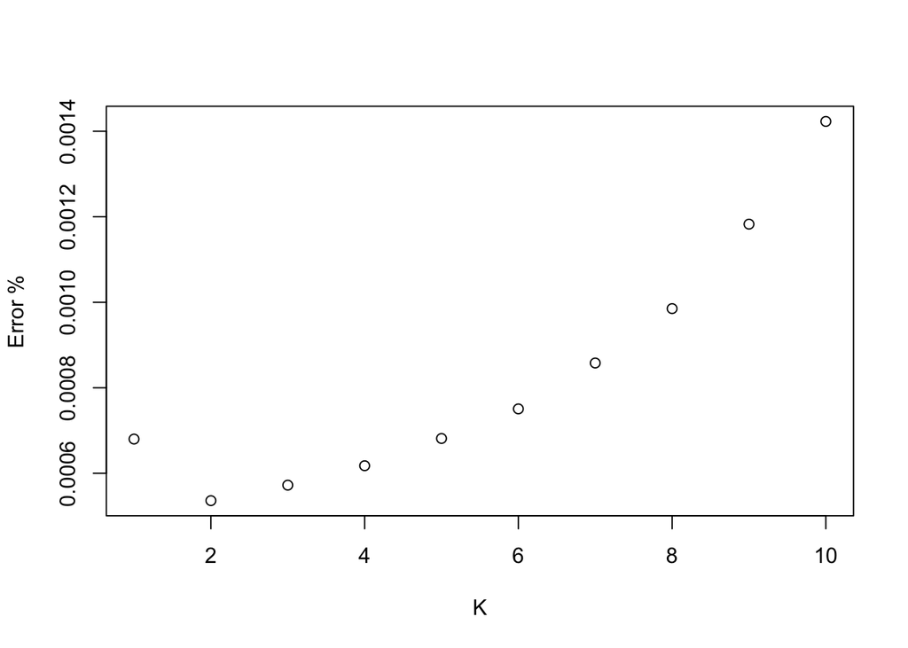

```r
set.seed(1234)
tk<- tune.knn(dbaDat[,-5],dbaDat$auth,k=1:10,tunecontrol=tune.control(sampling = "boot",nboot=200) )

plot(tk$performances$error,ylab="Error %", xlab = "K")
```

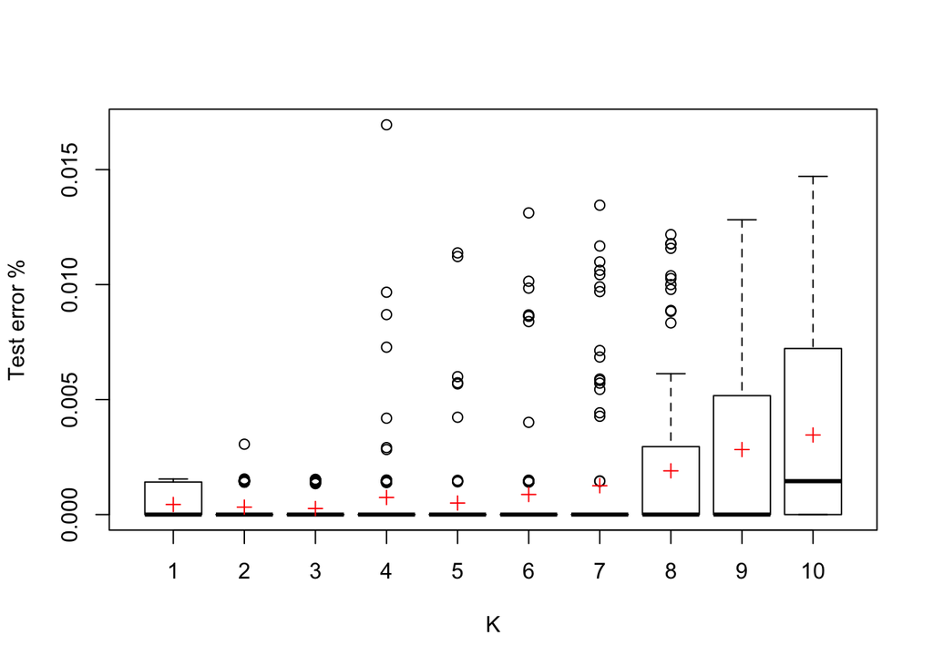

```r
#Here we can see that error is lowest when k=2, then starts to increase as we see underfitting and the error rate increases exponentially

#Resampling to get error distributions
set.seed(1234)
ce <- matrix(nrow=100,ncol=10)

for (k in seq(1,10)){
    for (j in 1:100){
      bTrain <- sample(c(FALSE,TRUE),nrow(dbaDat),replace=TRUE)
      cls <- as.factor(dbaDat$auth)
      tk1 <- knn(dbaDat[bTrain,],dbaDat[!bTrain,],k=k,cl=cls[bTrain])
      cm <- as.matrix(table(dbaDat[!bTrain,5],tk1))
      ce[j,k] <- 1-(sum(diag(cm))/sum(cm))
    }
}

boxplot(ce, xlab="K", ylab="Test error %")
points(colMeans(ce),pch=3, col="red")
```

```r
#Again, we see that for k=2 and 3, low test error rates as well as low variance. As the values of K increase, we get increasing number of outliers followed by an increase in mean error rates

#For k=2, we have observed 0 error rates, for low values of k, KNN seems to outperform both the forest and SVM. I'm assuming this is due to, despite very good performance on the other methods also, there is some data that is not linearly separable that knn just does a better job of fitting

set.seed(1)
knn.model <-knn(dbaDat[gTrain,],dbaDat[!gTrain,],k=2,cl=as.factor(gLbl[gTrain]))
knn.tab <- table(dbaDat[!gTrain,"auth"], knn.model)
knn.err <-  1-(sum(diag(knn.tab))/sum(knn.tab))
knn.err
```

```
## [1] 0
```